# Visualization with *ggplot2*

(A few remarks and tips before the practical session)

# R is the best technology for doing computational science

(Subjectively.)

# *ggplot2* is the most powerful visualization framework

(Objectively. 🙂)

## *ggplot2* is a core *tidyverse* package

[figure not shown]

## “Grammar of Graphics”

A formal syntax and grammar for describing visualizations

[figure not shown]

**What does this mean?**

## Let’s consider base R plotting

```r
library(palmerpenguins)

head(penguins, 7)
```

| species | island | bill_length_mm | bill_depth_mm | flipper_length_mm | body_mass_g | sex | year |
| --- | --- | --- | --- | --- | --- | --- | --- |
| Adelie | Torgersen | 39.1 | 18.7 | 181 | 3750 | male | 2007 |
| Adelie | Torgersen | 39.5 | 17.4 | 186 | 3800 | female | 2007 |
| Adelie | Torgersen | 40.3 | 18.0 | 195 | 3250 | female | 2007 |
| Adelie | Torgersen | NA | NA | NA | NA | NA | 2007 |
| Adelie | Torgersen | 36.7 | 19.3 | 193 | 3450 | female | 2007 |
| Adelie | Torgersen | 39.3 | 20.6 | 190 | 3650 | male | 2007 |
| Adelie | Torgersen | 38.9 | 17.8 | 181 | 3625 | female | 2007 |

## A base R histogram

```r
hist(penguins$body_mass_g)
```

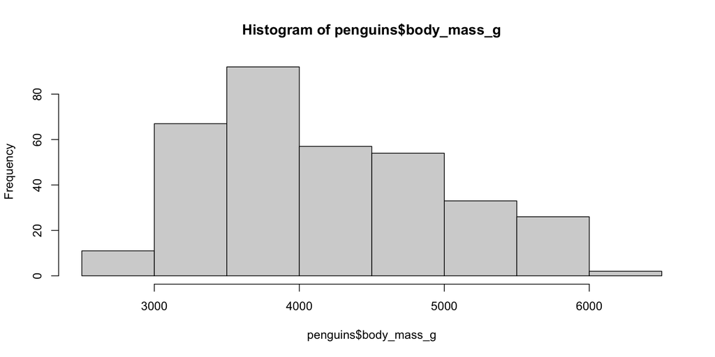

## A base R histogram

```r
hist(penguins$body_mass_g, xlim = c(2000, 8000))
```

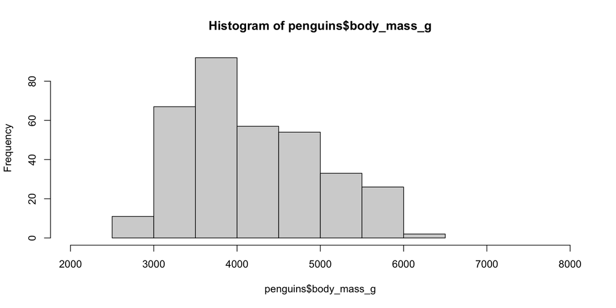

## A base R histogram

```r
hist(penguins$body_mass_g, xlim = c(2000, 8000),
     main = "Histogram of body mass of penguins")
```

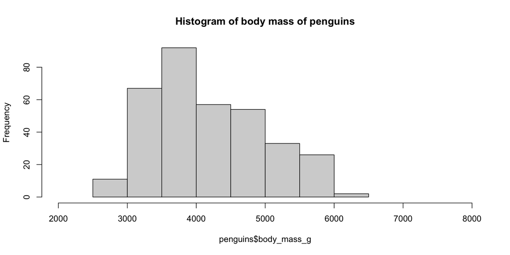

## A base R histogram

```r
hist(penguins$body_mass_g, xlim = c(2000, 8000),
     main = "Histogram of body mass of penguins",
     xlab = "Body mass [grams]")
```

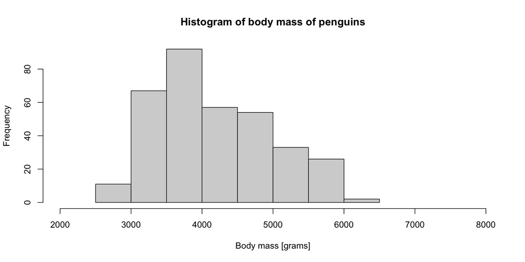

## A base R histogram

```r
hist(penguins$body_mass_g, xlim = c(2000, 8000),
     main = "Histogram of body mass of penguins",
     xlab = "Body mass [grams]",
     col = "black", border = "white")
```

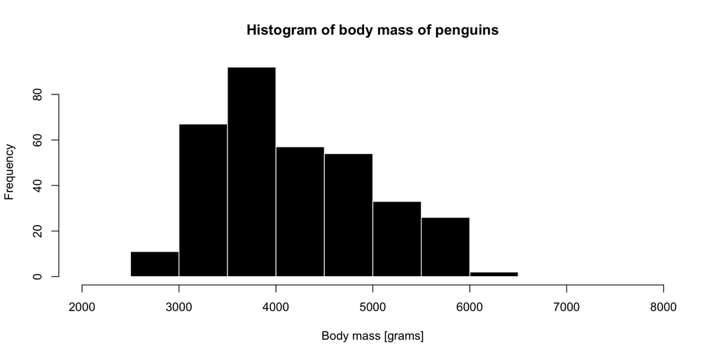

## A base R histogram

```r
par(mfrow = c(1, 3))

species_1 <- filter(penguins, species ==  "Adelie")
hist(species_1$body_mass_g, xlim = c(2000, 8000),
     main = "Species 'Adelie'",
     xlab = "Body mass [grams]",
     col = "darkgreen", border = "white")

species_2 <- filter(penguins, species ==  "Chinstrap")
hist(species_2$body_mass_g, xlim = c(2000, 8000),
     main = "Species 'Chinstrap'",
     xlab = "Body mass [grams]",
     col = "darkblue", border = "white")

species_3 <- filter(penguins, species ==  "Gentoo")
hist(species_3$body_mass_g, xlim = c(2000, 8000),
     main = "Species 'Gentoo'",
     xlab = "Body mass [grams]",
     col = "darkorange", border = "white")
```

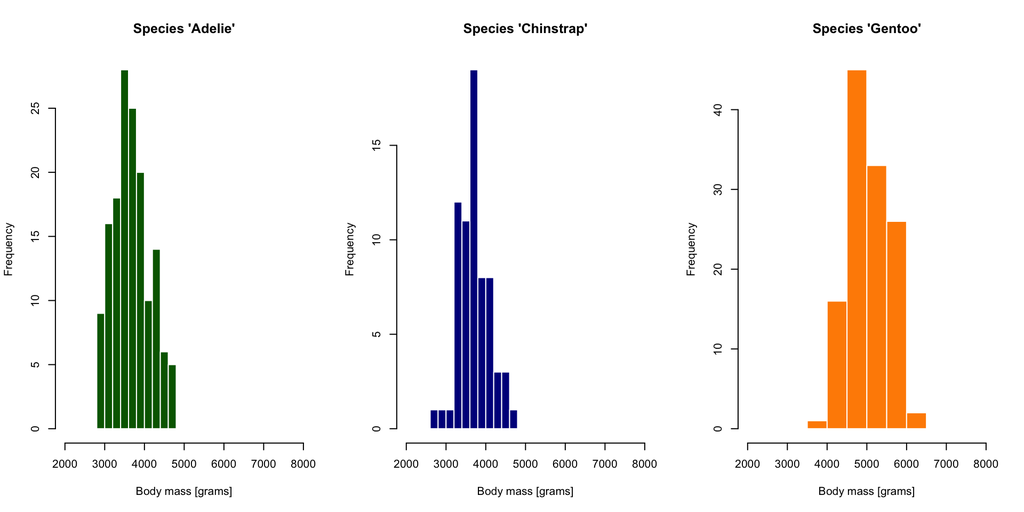

Base R plots use a single function and specify a (potentially large) number of parameters which change their “aesthetic” properties and visual elements.

**Creating a new figure (even from the same data) usually requires a completely different command.**

# *tidyverse* provides “grammar for data manipulation”…

A “mini-language” with verbs like `select()`, `filter()`, etc.

(Helps us avoid “R bootcamp”-level nightmares.)

# *ggplot2* provides “grammar for visualizations”…

(To make visualizations easier in a similar sense.)

## Layers in “Grammar of Graphics”

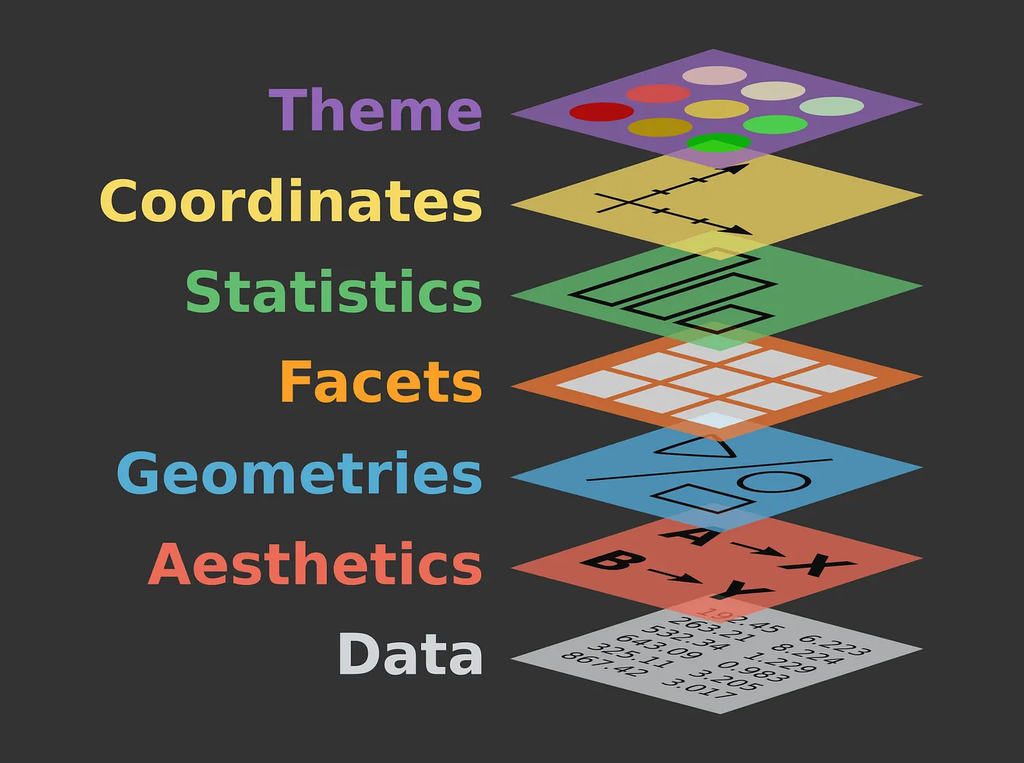

Illustration of Layers in Grammar of Graphics from [Quebec Centre for Biodiversity Science](https://r.qcbs.ca/)

## Layers in “Grammar of Graphics”

- `data` — our data frame
- `aesthetics` — “mapping” of columns to visual properties of a figure (`x`, or `y` axes, `color`, `shape`, etc.)
- `geoms` — graphical elements to be plotted (histograms, points, lines, etc.).
- many other customizations

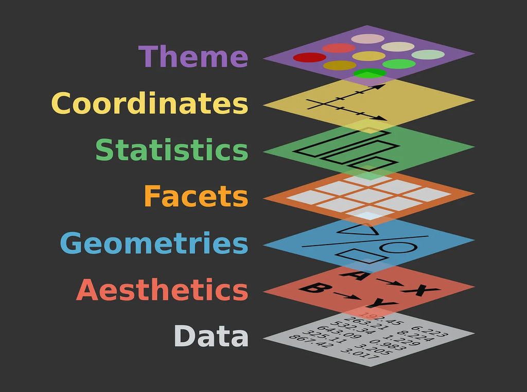